# HW2.rmd

John Drew

3/15/2021

## Introduction

In this analysis, the aims is to use the Comic Characters dataset from fivethiryeight.com answer the following three questions:  
1.In each year since 1961 and for both publishers combined, what percent of new characters are male versus female?  
2.What percent of good versus bad characters from each publisher are male versus female, since 1961?  
3.In each comic universe, do male characters or female characters, on average, have more appearances per character, just looking at years since 1961 and characters that appear in comics often(more than 100 appearances)

## Methods

For context, each row in the dataset represents a comic book character and contains information specific to that character. After getting familiarized with the data set, I have identified the variables of interest. The variables used to answer the above questions are: publisher, year, sex, align, and appearances. For ease of understanding, the following is a brief list describing each of the relevant variables.  
-Publisher is a categorical character variable that represents the publisher or Comic Universe that the character is from. The levels include Marvel and DC.  
-Year is a continuous numerical variable that represents the year of a characters first appearance.  
-Sex is a categorical character variable that represents the Gender of a character. The levels include: Agender Characters, Female Characters, Genderfluid Characters, Genderless Characters, Male Characters, and Transgender Characters. For our purposes though, we will only be focusing on Male and Female Characters.  
-Align is a categorical character variable that represents the “side” a character is on. The levels include: Bad Characters, Reformed Criminals, Netural Characters, Good Characters. However, we will only be focusing on Good and Bad Characters.  
-Appearances is a continuous numerical variable that represents the number of times a character has appeared in comic books. This is particularly helpful when analyzed along side year.

## Results

### Question 1

-In each year since 1961 and for both publishers combined, what percent of new characters are male versus female?

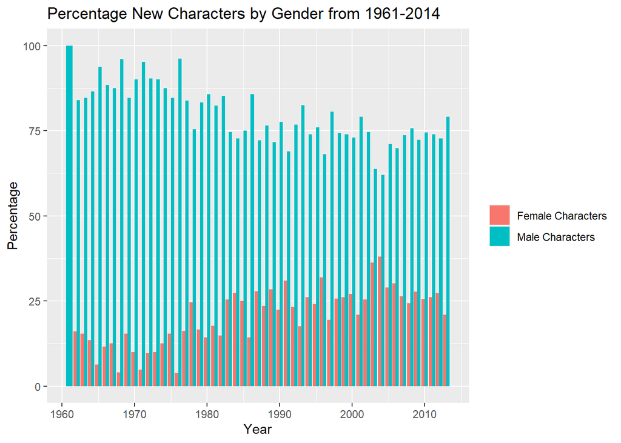

### Question 2

-What percent of good versus bad characters from each publisher are male versus female, since 1961?

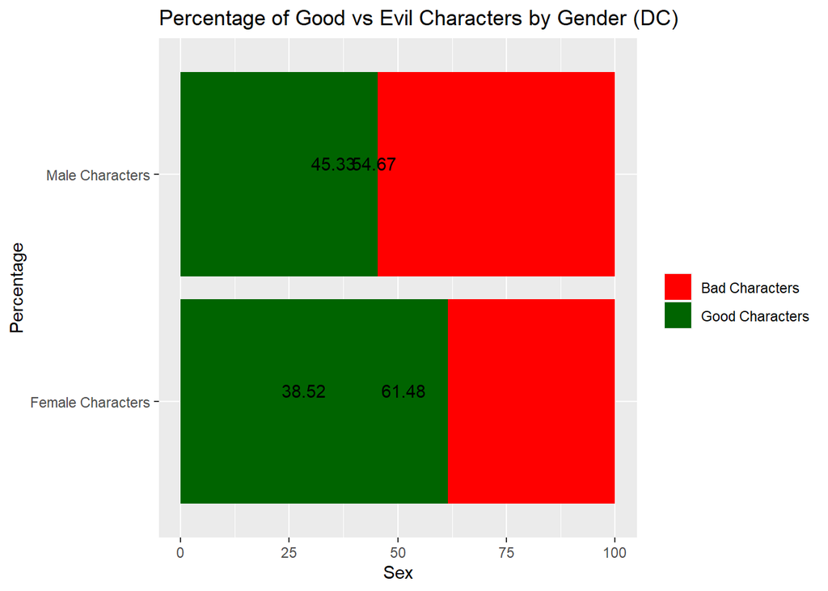

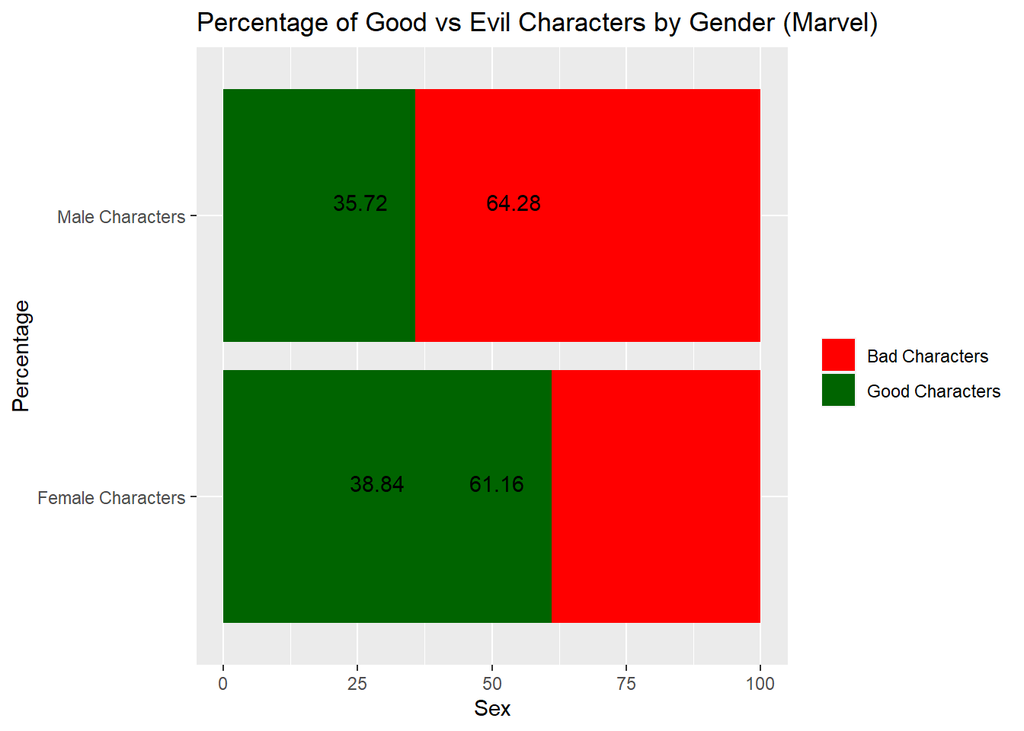

### Question 3

-In each comic universe, do male characters or female characters, on average, have more appearances per character, just looking at years since 1961 and characters that appear in comics often(more than 100 appearances)

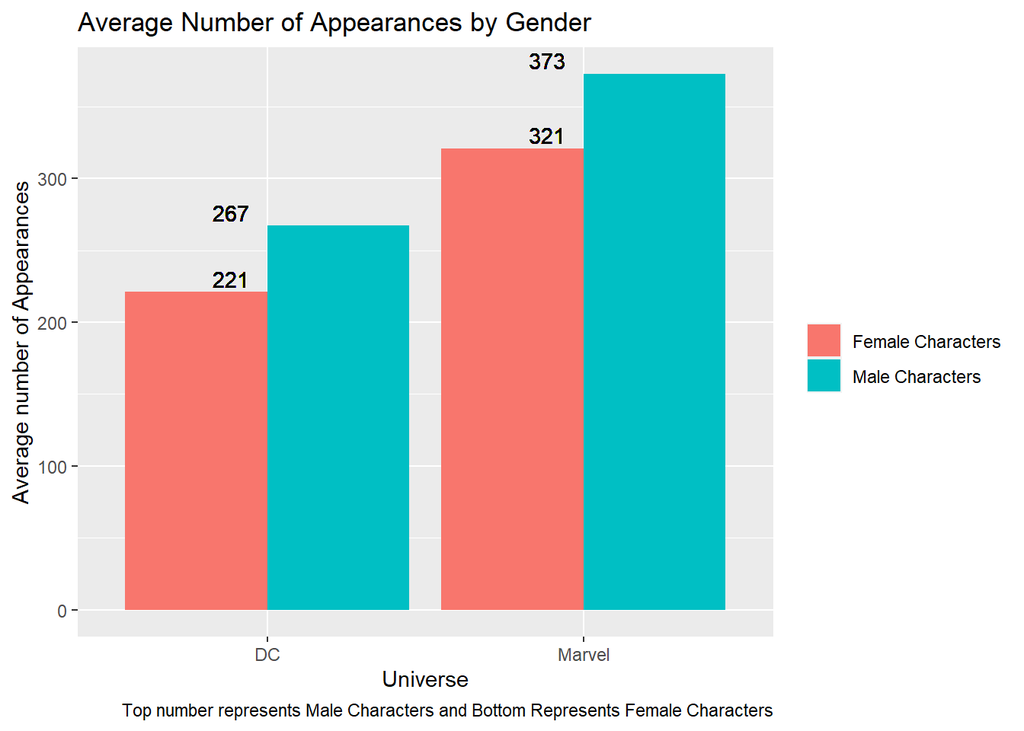